# Virtual Observatory at susseX (VOX) Introduction

[figure not shown]

The Virtual Observatory at susseX (VOX) is a virtual observatory server built using the German Astrophysical Virtual Observatory (GAVO) DaCHS software: [*Data Center Helper Suite*](https://dachs-doc.readthedocs.io). VOX contains both the maps and the catalogue data.

Maps are available through the *Simple Image Access Protocol* (SIAP). In particular, VOX makes is possible to get image cutouts at a given position.

The catalogue data is gathered into a single table across all the coverage that users can query using the *Table Access Protocol* (TAP) with compliant software like TOPCAT , STILTS or [PyVO](https://pyvo.readthedocs.io). This allows users to make sophisticated queries or to remotely crossmatch their catalogues with HELP data.

In this notebook, we will go through some simple examples to introduce you to HELP data and using the VOX.

```python
!pip install pyvo
```

```
     |████████████████████████████████| 808kB 5.4MB/s
```

```python
!pip install aplpy
```

```
     |████████████████████████████████| 92kB 4.1MB/s
     |████████████████████████████████| 1.1MB 10.3MB/s
     |████████████████████████████████| 378kB 35.4MB/s
     |████████████████████████████████| 1.3MB 28.7MB/s
     |████████████████████████████████| 215kB 44.0MB/s
```

```python
from astropy.io import ascii, fits
from astropy import units as u
from astropy.coordinates import SkyCoord
import aplpy
import numpy as np
from astropy.table import Table
import pylab as plt
import seaborn as sns
%matplotlib inline
from astropy import wcs
import pyvo as vo
```

```
WARNING: AstropyDeprecationWarning: block_reduce was moved to the astropy.nddata.blocks module.  Please update your import statement. [astropy.nddata.utils]
```

## Example 1: Get sources located near a single position

A very simple use case to get started with is to find all sources close to a specific position. We do this by using the TAP protocol and writing queries in the Astronomical Data Query Language (ADQL), a dialect of the Standard Query Language SQL. Its purpose is to give you a formal language to specify what data you are interested in.

To get started using ADQL, try this [ADQL course](http://docs.g-vo.org/adql). There are plenty of introductions SQL itself, which are perfectly useful for learning ADQL. Check your local bookstore. Online, [A Gentle Introduction to SQL](http://sqlzoo.net/) or chapter three of [Practical PostgreSQL](http://www.faqs.org/docs/ppbook/book1.htm) might be useful; for the purposes of learning ADQL, you can skip everything talking about "DDL" in general introductions.

For this example we need to specify a right accension and declination, and a search radius

```python
RA=161.63
Dec=59.17
radius=0.028
```

We also need to create a TAP service that connects to VOX which we can search

```python
service = vo.dal.TAPService("https://herschel-vos.phys.sussex.ac.uk/__system__/tap/run/tap")
```

Having connected to the service, we now need to write our query, send it to VOX and get our results back.

To write the query, we:

- use the `SELECT` operational statement and ask for the `TOP 10000` results (VOX has a default maximum return of 2000 rows, so we explicitly specify 10000 to override this).
- Tell the VO to get the results `FROM herschelhelp.main`, i.e. the main HELP masterlist. You can find the other tables you could use [here](https://herschel-vos.phys.sussex.ac.uk/__system__/dc_tables/list/form).
- Specify that only objects within our search radius from our chosen point are returned. We do this using the `WHERE` condition and `CONTAINS(POINT('ICRS', ra, dec),CIRCLE('ICRS',"+str(RA)+", "+str(Dec)+","+str(radius)+" ))")` The `CONTAINS()` return either 0 if False and 1 if True.

```python
resultset = service.search("SELECT TOP 10000 * FROM herschelhelp.main WHERE 1=CONTAINS(POINT('ICRS', ra, dec),CIRCLE('ICRS',"+str(RA)+", "+str(Dec)+","+str(radius)+" ))")
```

The above command can take a couple of seconds to run (depending on how complicated or large the query). We can then foramt the results into a table.

```python
masterlist=resultset.to_table()
```

```python
masterlist
```

*Table length=748*

| field object | help_id object | ra deg float64 | dec deg float64 | hp_idx int64 | ebv float64 | redshift float32 | zspec float32 | zspec_qual int16 | zspec_association_flag bool | stellarity float64 | stellarity_origin object | f_90prime_g uJy float64 | ferr_90prime_g uJy float64 | f_ap_90prime_g uJy float64 | ferr_ap_90prime_g uJy float64 | m_90prime_g mag float64 | merr_90prime_g mag float64 | m_ap_90prime_g mag float64 | merr_ap_90prime_g mag float64 | flag_90prime_g bool | f_90prime_r uJy float64 | ferr_90prime_r uJy float64 | f_ap_90prime_r uJy float64 | ferr_ap_90prime_r uJy float64 | m_90prime_r mag float64 | merr_90prime_r mag float64 | m_ap_90prime_r mag float64 | merr_ap_90prime_r mag float64 | flag_90prime_r bool | … |
| --- | --- | --- | --- | --- | --- | --- | --- | --- | --- | --- | --- | --- | --- | --- | --- | --- | --- | --- | --- | --- | --- | --- | --- | --- | --- | --- | --- | --- | --- | --- |
| Lockman SWIRE | HELP_J104635.978+591143.462 | 161.649908443498 | 59.1954060394688 | 99580067 | 0.00668978317698605 | -- | -- | -99 | False | 0.525363981723785 | sparcs_stellarity | -- | -- | -- | -- | -- | -- | -- | -- | -- | -- | -- | -- | -- | -- | -- | -- | -- | -- | … |
| Lockman SWIRE | HELP_J104631.224+591152.487 | 161.630098216702 | 59.1979130228532 | 99580072 | 0.00654793308961096 | 0.5674 | -- | -99 | False | 0.87 | servs_stellarity_ira | -- | -- | -- | -- | -- | -- | -- | -- | -- | -- | -- | -- | -- | -- | -- | -- | -- | -- | … |
| Lockman SWIRE | HELP_J104630.626+591152.138 | 161.627610066244 | 59.1978160892855 | 99580072 | 0.00653435075388294 | -- | -- | -99 | False | 0.40082123875618 | sparcs_stellarity | -- | -- | -- | -- | -- | -- | -- | -- | -- | -- | -- | -- | -- | -- | -- | -- | -- | -- | … |
| Lockman SWIRE | HELP_J104629.944+591151.286 | 161.624764882636 | 59.1975794186438 | 99577341 | 0.00652022856134222 | -- | -- | -99 | False | 0.353524833917618 | sparcs_stellarity | -- | -- | -- | -- | -- | -- | -- | -- | -- | -- | -- | -- | -- | -- | -- | -- | -- | -- | … |
| Lockman SWIRE | HELP_J104629.518+591151.902 | 161.622990229111 | 59.197750462134 | 99577343 | 0.00650814542978448 | -- | -- | -99 | False | 0.575287520885468 | sparcs_stellarity | -- | -- | -- | -- | -- | -- | -- | -- | -- | -- | -- | -- | -- | -- | -- | -- | -- | -- | … |
| Lockman SWIRE | HELP_J104630.173+591151.559 | 161.625719945903 | 59.1976553144346 | 99580072 | 0.00652499113046838 | -- | -- | -99 | False | 0.366399258375168 | sparcs_stellarity | -- | -- | -- | -- | -- | -- | -- | -- | -- | -- | -- | -- | -- | -- | -- | -- | -- | -- | … |
| Lockman SWIRE | HELP_J104629.742+591148.859 | 161.623926417432 | 59.1969053931639 | 99577341 | 0.00652240152681751 | -- | -- | -99 | False | 0.362470060586929 | sparcs_stellarity | -- | -- | -- | -- | -- | -- | -- | -- | -- | -- | -- | -- | -- | -- | -- | -- | -- | -- | … |
| Lockman SWIRE | HELP_J104629.208+591150.660 | 161.621701260268 | 59.1974056626213 | 99577343 | 0.00650431616308627 | -- | -- | -99 | False | 0.413240402936935 | sparcs_stellarity | -- | -- | -- | -- | -- | -- | -- | -- | -- | -- | -- | -- | -- | -- | -- | -- | -- | -- | … |
| Lockman SWIRE | HELP_J104628.970+591150.623 | 161.620707060025 | 59.1973952157498 | 99577343 | 0.00649869552548155 | 2.0472 | -- | -99 | False | 0.449999988079071 | rcs_stellarity | -- | -- | -- | -- | -- | -- | -- | -- | -- | -- | -- | -- | -- | -- | -- | -- | -- | -- | … |
| ... | ... | ... | ... | ... | ... | ... | ... | ... | ... | ... | ... | ... | ... | ... | ... | ... | ... | ... | ... | ... | ... | ... | ... | ... | ... | ... | ... | ... | ... | … |
| Lockman SWIRE | HELP_J104623.033+590859.354 | 161.595969736265 | 59.1498205225632 | 99577304 | 0.006845194892044 | -- | -- | -99 | False | 0.35 | servs_stellarity_ira | -- | -- | -- | -- | -- | -- | -- | -- | -- | -- | -- | -- | -- | -- | -- | -- | -- | -- | … |
| Lockman SWIRE | HELP_J104621.497+590909.173 | 161.589570313943 | 59.1525481691748 | 99577304 | 0.0068044389604719 | -- | -- | -99 | False | 0.482799291610718 | sparcs_stellarity | -- | -- | -- | -- | -- | -- | -- | -- | -- | -- | -- | -- | -- | -- | -- | -- | -- | -- | … |
| Lockman SWIRE | HELP_J104624.428+590857.089 | 161.601781360024 | 59.1491915157497 | 99577298 | 0.00686442917086261 | 2.3678 | -- | -99 | False | 0.360000014305115 | rcs_stellarity | -- | -- | -- | -- | -- | -- | -- | -- | -- | -- | -- | -- | -- | -- | -- | -- | -- | -- | … |
| Lockman SWIRE | HELP_J104623.887+590858.399 | 161.599529998703 | 59.1495553208533 | 99577298 | 0.00685591281068798 | 0.465 | -- | -99 | False | 0.98 | servs_stellarity_ira | -- | -- | -- | -- | -- | -- | -- | -- | -- | -- | -- | -- | -- | -- | -- | -- | -- | -- | … |
| Lockman SWIRE | HELP_J104624.043+590854.298 | 161.600177287778 | 59.148416174642 | 99577298 | 0.00686738787330717 | 5.6588 | -- | -99 | False | 0.993865013122559 | dxs_stellarity | -- | -- | -- | -- | -- | -- | -- | -- | -- | -- | -- | -- | -- | -- | -- | -- | -- | -- | … |
| Lockman SWIRE | HELP_J104623.166+590855.019 | 161.59652452839 | 59.1486164330944 | 99577304 | 0.00685734591586921 | -- | -- | -99 | False | 0.540187060832977 | sparcs_stellarity | -- | -- | -- | -- | -- | -- | -- | -- | -- | -- | -- | -- | -- | -- | -- | -- | -- | -- | … |
| Lockman SWIRE | HELP_J104625.801+590845.379 | 161.607504352352 | 59.1459385032006 | 99577299 | 0.0069047143549412 | 1.4662 | -- | -99 | False | 0.86 | servs_stellarity_ira | -- | -- | -- | -- | -- | -- | -- | -- | -- | -- | -- | -- | -- | -- | -- | -- | -- | -- | … |
| Lockman SWIRE | HELP_J104624.898+590845.343 | 161.603741036265 | 59.1459287225632 | 99577298 | 0.0068965001422885 | -- | -- | -99 | False | 0.4 | servs_stellarity_ira | -- | -- | -- | -- | -- | -- | -- | -- | -- | -- | -- | -- | -- | -- | -- | -- | -- | -- | … |
| Lockman SWIRE | HELP_J104625.492+590842.998 | 161.606214932347 | 59.1452771744105 | 99577297 | 0.00690720514550813 | -- | -- | -99 | False | 0.516168177127838 | sparcs_stellarity | -- | -- | -- | -- | -- | -- | -- | -- | -- | -- | -- | -- | -- | -- | -- | -- | -- | -- | … |
| Lockman SWIRE | HELP_J104626.441+590840.362 | 161.610169236264 | 59.1445450225632 | 99577297 | 0.0069214538809967 | -- | -- | -99 | False | 0.36 | servs_stellarity_ira | -- | -- | -- | -- | -- | -- | -- | -- | -- | -- | -- | -- | -- | -- | -- | -- | -- | -- | … |

As you can see, the `masterlist` has returned all the sources we are interested in. Lets do a simple plot to check

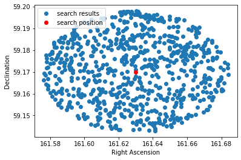

```python
plt.plot(masterlist['ra'],masterlist['dec'], 'o',label='search results')
plt.plot(RA,Dec,'ro',label='search position')
plt.xlabel('Right Ascension')
plt.ylabel('Declination')
plt.legend()
```

## Example 2: Get SPIRE cutouts for position

Having searched the HELP database to get sources, it would be useful to see what the SPIRE maps look like for this position. We can do that using the simple image access protocol (SIAP). SIAP is simple for maps that overlaps (or contains, or are contained by) a region of interest defined by a position and a radius. The cutout service has additional parameters as the `cutoutSize` that allows the server to return a link to a cropped version of the map.

We need the endpoint of the SIAP service of the cutout resource that can be found on https://herschel-vos.phys.sussex.ac.uk/herschel_maps/q/cutout/info

```python
cutout_service = vo.dal.SIAService(f"https://herschel-vos.phys.sussex.ac.uk/herschel_maps/q/cutout/siap.xml")
```

We can ask for the service parameters that are additional to the standard SIAP parameters:

```python
cutout_service.params
```

```
[<PARAM ID="INPUT_POS" arraysize="*" datatype="char" name="INPUT:POS" ucd="pos.eq" unit="deg" value=""/>,
 <PARAM ID="INPUT_SIZE" arraysize="*" datatype="char" name="INPUT:SIZE" unit="deg" value=""/>,
 <PARAM ID="INPUT_INTERSECT" arraysize="*" datatype="char" name="INPUT:INTERSECT" value="OVERLAPS"/>,
 <PARAM ID="INPUT_FORMAT" arraysize="*" datatype="char" name="INPUT:FORMAT" value="GRAPHIC"/>,
 <PARAM ID="INPUT_bandpassId" arraysize="*" datatype="char" name="INPUT:bandpassId" ucd="VOX:BandPass_ID" value=""/>,
 <PARAM ID="INPUT_type" arraysize="*" datatype="char" name="INPUT:type" ucd="meta.code" value=""/>,
 <PARAM ID="INPUT_cutoutSize" datatype="float" name="INPUT:cutoutSize" unit="deg" value="0.1"/>,
 <PARAM ID="INPUT_RESPONSEFORMAT" arraysize="*" datatype="char" name="INPUT:RESPONSEFORMAT" ucd="meta.code.mime" value=""/>,
 <PARAM ID="INPUT_MAXREC" datatype="int" name="INPUT:MAXREC" value="0"/>,
 <PARAM ID="INPUT_VERB" datatype="int" name="INPUT:VERB" value="0"/>]
```

As we can see, there is `cutoutSize` that is used the give the size of the cutout we want but there are also parameters added by HELP:

- `type` which defines that kind of image: `image`, `error`, or `exposure`
- `bandpassId` that identifies the SPIRE band: `SPIRE250`, `SPIRE350`, or `SPIRE500`.

Note that there are two size parameters: `size` is the radius defining the region of interest around the position that is used to look for maps. It's a standard SIAP parameter and is given with its associated unit; `cutoutSize` is the width of the cutout around the position the user want in the maps overlapping the region of interest; it may be different than the size (and should be double the radius if you want the cutout corresponding to the searched region) and must be given in degrees without units.

Let's look for the SPIRE250 image and error maps.

```python
pos = SkyCoord(RA * u.deg, Dec * u.deg)
```

```python
images = cutout_service.search(
    pos=pos,
    size=radius,
    cutoutSize=2*radius,
    bandpassId='SPIRE250',
    type=['image', 'error']
)
```

the result is a pyvo.dal.sia.SIAResults that can be converted to a table.

```python
images = images.to_table()
images
```

*Table length=4*

| accref object | mime object | accsize byte int32 | centerAlpha deg float64 | centerDelta deg float64 | imageTitle object | instId object | dateObs d float64 | nAxes int32 | pixelSize pix object | pixelScale deg / pix object | refFrame object | wcs_equinox yr float32 | wcs_projection str3 | wcs_refPixel pix object | wcs_refValues deg object | wcs_cdmatrix deg / pix object | bandpassId object | bandpassUnit object | bandpassRefval m float64 | bandpassHi m float64 | bandpassLo m float64 | pixflags object | coverage deg object | field object | type object |
| --- | --- | --- | --- | --- | --- | --- | --- | --- | --- | --- | --- | --- | --- | --- | --- | --- | --- | --- | --- | --- | --- | --- | --- | --- | --- |
| https://herschel-vos.phys.sussex.ac.uk/getproduct/herschel_maps/data/Lockman-NEST_error_250_SMAP_v6.0.fits?sdec=0.056&dec=59.17&ra=161.63&sra=0.109269882158 | image/fits | 2259 | 161.63 | 59.17 | Lockman-SWIRE SPIRE250 (error) | SPIRE | -- | 2 | [3757 3502] | [0.00166667 0.00166667] | ICRS | 2000.0 | TAN | [16.693389221607504 -16.911389575368048] | [161.63 59.17] | [-0.00166667 0.0 0.0 0.00166667] | SPIRE250 | m | -- | -- | -- |  | [166.6955173810341 55.01985901923391 167.6573019612306 60.81886471892404 154.82768339076915 60.81886471892404 155.7894679709656 55.01985901923391] | Lockman-SWIRE | error |
| https://herschel-vos.phys.sussex.ac.uk/getproduct/herschel_maps/data/Lockman-NEST_image_250_SMAP_v6.0.fits?sdec=0.056&dec=59.17&ra=161.63&sra=0.109269882158 | image/fits | 2259 | 161.63 | 59.17 | Lockman-SWIRE SPIRE250 (image) | SPIRE | -- | 2 | [3757 3502] | [0.00166667 0.00166667] | ICRS | 2000.0 | TAN | [16.693389221607504 -16.911389575368048] | [161.63 59.17] | [-0.00166667 0.0 0.0 0.00166667] | SPIRE250 | m | -- | -- | -- |  | [166.6955173810341 55.01985901923391 167.6573019612306 60.81886471892404 154.82768339076915 60.81886471892404 155.7894679709656 55.01985901923391] | Lockman-SWIRE | image |
| https://herschel-vos.phys.sussex.ac.uk/getproduct/herschel_maps/data/Lockman_error_250_SMAP_v6.0.fits?sdec=0.056&dec=59.17&ra=161.63&sra=0.109269882158 | image/fits | 2259 | 161.63 | 59.17 | Lockman-SWIRE (shallow) SPIRE250 (error) | SPIRE | -- | 2 | [3757 3502] | [0.00166667 0.00166667] | ICRS | 2000.0 | TAN | [16.693389221607504 -16.911389575368048] | [161.63 59.17] | [-0.00166667 0.0 0.0 0.00166667] | SPIRE250 | m | -- | -- | -- |  | [166.6955173810341 55.01985901923391 167.6573019612306 60.81886471892404 154.82768339076915 60.81886471892404 155.7894679709656 55.01985901923391] | Lockman-SWIRE | error |
| https://herschel-vos.phys.sussex.ac.uk/getproduct/herschel_maps/data/Lockman_image_250_SMAP_v6.0.fits?sdec=0.056&dec=59.17&ra=161.63&sra=0.109269882158 | image/fits | 2259 | 161.63 | 59.17 | Lockman-SWIRE (shallow) SPIRE250 (image) | SPIRE | -- | 2 | [3757 3502] | [0.00166667 0.00166667] | ICRS | 2000.0 | TAN | [16.693389221607504 -16.911389575368048] | [161.63 59.17] | [-0.00166667 0.0 0.0 0.00166667] | SPIRE250 | m | -- | -- | -- |  | [166.6955173810341 55.01985901923391 167.6573019612306 60.81886471892404 154.82768339076915 60.81886471892404 155.7894679709656 55.01985901923391] | Lockman-SWIRE | image |

```python
spire250_image_map = fits.open(
    images[images['type'] == 'image'][1]['accref'])
```

Lets plot our map using the astronomy plotting Python module [`aplpy`](https://aplpy.github.io/) and plot the sources we found using the VOX server.

```
INFO: Auto-setting vmin to -1.595e-02 [aplpy.core]
INFO: Auto-setting vmax to  2.570e-02 [aplpy.core]
```

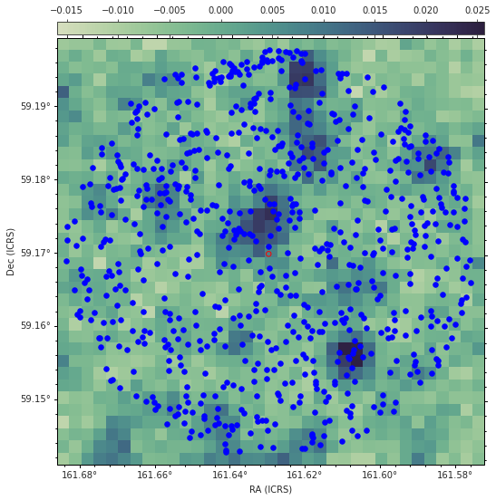

```python
sns.set_style("white")
cmap=sns.cubehelix_palette(8, start=.5, rot=-.75,as_cmap=True)
fig=aplpy.FITSFigure(spire250_image_map)
fig.show_colorscale(cmap=cmap)
fig.show_markers(RA,Dec)
fig.show_markers(masterlist['ra'],masterlist['dec'], edgecolor='blue', facecolor='blue')
fig.tick_labels.set_xformat('dd.dd')
fig.tick_labels.set_yformat('dd.dd')
fig.add_colorbar()
fig.colorbar.set_location('top')
```

As you can see here, the resolution of the SPIRE map compared to the number of sources is very low, and leads to the problem of source confusion (not knowing what the sources in the SPIRE map correspond to the sources from masterlist). We developed XID+; a probabilistic deblender to deal with this problem. Other examples demonstrate how to use XID+.

### Exploring the dataset

Now that we have got our returned table and image, we can explore some of the columns and properties contained within the table, for example we can look at the distributions of photometric redshifts

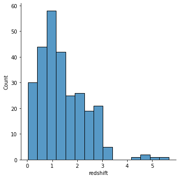

```python
sns.displot(x=masterlist['redshift'])
```

Look at distributions of SPIRE flux

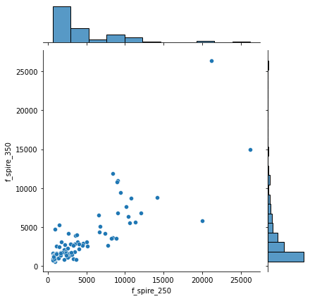

```python
sns.jointplot(x=masterlist['f_spire_250'],y=masterlist['f_spire_350'])
```

See how many objects have SED fits with CIGALE. We do this by seeing where `cigale_mstar` is masked, and inverting. This will give us a boolean array, where objects with fits are now TRUE. We can now sum this array to get how many of the objects have fits

```python
print('there are {} objects out of {} with cigale fits'.format(np.invert(masterlist['cigale_mstar'].mask).sum(),len(masterlist)))
```

```
there are 5 objects out of 748 with cigale fits
```

CIGALE has physical parameters such as starformation rate and stellar mass, lets look at the joint distribution.

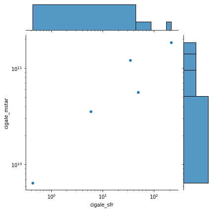

```python
g=sns.jointplot(masterlist['cigale_sfr'],masterlist['cigale_mstar'])
g.ax_joint.set_xscale('log')
g.ax_joint.set_yscale('log')
```

This notebook is a brief introduction into using both the TAP and SIAP protocols for accessing catalogue and image data from HELP's VOX. We encourage you to use these notebooks to create more complex queries and exploit the HELP data for science.

Other example notebooks demonstrate some other useful queries and how to use other HELP tools such as XID+

[figure not shown]

**Authors**: Peter Hurley

The Herschel Extragalactic Legacy Project, (HELP), is a European Commission Research Executive Agency funded project under the SP1-Cooperation, Collaborative project, Small or medium-scale focused research project, FP7-SPACE-2013-1 scheme, Grant Agreement Number 607254.